# Project Python Foundations: FoodHub Data Analysis

### Context

The number of restaurants in New York is increasing day by day. Lots of students and busy professionals rely on those restaurants due to their hectic lifestyles. Online food delivery service is a great option for them. It provides them with good food from their favorite restaurants. A food aggregator company FoodHub offers access to multiple restaurants through a single smartphone app.

The app allows the restaurants to receive a direct online order from a customer. The app assigns a delivery person from the company to pick up the order after it is confirmed by the restaurant. The delivery person then uses the map to reach the restaurant and waits for the food package. Once the food package is handed over to the delivery person, he/she confirms the pick-up in the app and travels to the customer's location to deliver the food. The delivery person confirms the drop-off in the app after delivering the food package to the customer. The customer can rate the order in the app. The food aggregator earns money by collecting a fixed margin of the delivery order from the restaurants.

### Objective

The food aggregator company has stored the data of the different orders made by the registered customers in their online portal. They want to analyze the data to get a fair idea about the demand of different restaurants which will help them in enhancing their customer experience. Suppose you are hired as a Data Scientist in this company and the Data Science team has shared some of the key questions that need to be answered. Perform the data analysis to find answers to these questions that will help the company to improve the business.

### Data Description

The data contains the different data related to a food order. The detailed data dictionary is given below.

### Data Dictionary

- order_id: Unique ID of the order
- customer_id: ID of the customer who ordered the food
- restaurant_name: Name of the restaurant
- cuisine_type: Cuisine ordered by the customer
- cost_of_the_order: Cost of the order
- day_of_the_week: Indicates whether the order is placed on a weekday or weekend (The weekday is from Monday to Friday and the weekend is Saturday and Sunday)
- rating: Rating given by the customer out of 5
- food_preparation_time: Time (in minutes) taken by the restaurant to prepare the food. This is calculated by taking the difference between the timestamps of the restaurant's order confirmation and the delivery person's pick-up confirmation.
- delivery_time: Time (in minutes) taken by the delivery person to deliver the food package. This is calculated by taking the difference between the timestamps of the delivery person's pick-up confirmation and drop-off information

### Let us start by importing the required libraries

```python
# Installing the libraries with the specified version.
!pip install numpy==1.25.2 pandas==1.5.3 matplotlib==3.7.1 seaborn==0.13.1 -q --user
```

[output not shown]

**Note**: *After running the above cell, kindly restart the notebook kernel and run all cells sequentially from the start again.*

```python
# import libraries for data manipulation
import numpy as np
import pandas as pd

# import libraries for data visualization
import matplotlib.pyplot as plt
import seaborn as sns
```

### Understanding the structure of the data

```python
from google.colab import drive
drive.mount('/content/drive')
```

```python
# read the data
data = pd.read_csv('/content/drive/MyDrive/Colab Notebooks/foodhub_order.csv')
```

```python
# view the first 5 rows
data.head()
```

|  | order_id | customer_id | restaurant_name | cuisine_type | cost_of_the_order | day_of_the_week | rating | food_preparation_time | delivery_time |
| --- | --- | --- | --- | --- | --- | --- | --- | --- | --- |
| 0 | 1477147 | 337525 | Hangawi | Korean | 30.75 | Weekend | Not given | 25 | 20 |
| 1 | 1477685 | 358141 | Blue Ribbon Sushi Izakaya | Japanese | 12.08 | Weekend | Not given | 25 | 23 |
| 2 | 1477070 | 66393 | Cafe Habana | Mexican | 12.23 | Weekday | 5 | 23 | 28 |
| 3 | 1477334 | 106968 | Blue Ribbon Fried Chicken | American | 29.20 | Weekend | 3 | 25 | 15 |
| 4 | 1478249 | 76942 | Dirty Bird to Go | American | 11.59 | Weekday | 4 | 25 | 24 |

```python
#Code to see 10 random rows
data.sample(10)
```

|  | order_id | customer_id | restaurant_name | cuisine_type | cost_of_the_order | day_of_the_week | rating | food_preparation_time | delivery_time |
| --- | --- | --- | --- | --- | --- | --- | --- | --- | --- |
| 1799 | 1477259 | 145952 | Blue Ribbon Sushi | Japanese | 29.15 | Weekend | 4 | 31 | 19 |
| 264 | 1477909 | 47440 | Blue Ribbon Fried Chicken | American | 12.18 | Weekend | Not given | 31 | 23 |
| 86 | 1476796 | 78939 | Nobu Next Door | Japanese | 16.30 | Weekday | 3 | 20 | 24 |
| 456 | 1478046 | 53289 | The Loop | Japanese | 31.38 | Weekend | 4 | 26 | 24 |
| 181 | 1476610 | 53212 | TAO | Japanese | 12.27 | Weekday | Not given | 26 | 29 |
| 314 | 1478229 | 64153 | Blue Ribbon Fried Chicken | American | 21.34 | Weekend | Not given | 35 | 23 |
| 1057 | 1477947 | 78560 | The Meatball Shop | Italian | 12.18 | Weekend | 3 | 27 | 20 |
| 439 | 1478355 | 68103 | The Meatball Shop | Italian | 21.83 | Weekend | 4 | 30 | 20 |
| 1571 | 1476547 | 83095 | Bareburger | American | 6.84 | Weekend | 5 | 22 | 24 |
| 1544 | 1476674 | 318689 | Olive Garden | Italian | 16.10 | Weekday | Not given | 24 | 29 |

```python
data.tail()
```

|  | order_id | customer_id | restaurant_name | cuisine_type | cost_of_the_order | day_of_the_week | rating | food_preparation_time | delivery_time |
| --- | --- | --- | --- | --- | --- | --- | --- | --- | --- |
| 1893 | 1476701 | 292602 | Chipotle Mexican Grill $1.99 Delivery | Mexican | 22.31 | Weekend | 5 | 31 | 17 |
| 1894 | 1477421 | 397537 | The Smile | American | 12.18 | Weekend | 5 | 31 | 19 |
| 1895 | 1477819 | 35309 | Blue Ribbon Sushi | Japanese | 25.22 | Weekday | Not given | 31 | 24 |
| 1896 | 1477513 | 64151 | Jack's Wife Freda | Mediterranean | 12.18 | Weekday | 5 | 23 | 31 |
| 1897 | 1478056 | 120353 | Blue Ribbon Sushi | Japanese | 19.45 | Weekend | Not given | 28 | 24 |

### **Question 1:** How many rows and columns are present in the data? [0.5 mark]

```python
print("There are", data.shape[0], 'rows and', data.shape[1], "columns.")
```

```
There are 1898 rows and 9 columns.
```

#### Observations:

There are 1898 rows and 9 columns.

### **Question 2:** What are the datatypes of the different columns in the dataset? (The info() function can be used) [0.5 mark]

```python
# Write your code here
data.info()
```

```
<class 'pandas.core.frame.DataFrame'>
RangeIndex: 1898 entries, 0 to 1897
Data columns (total 9 columns):
 #   Column                 Non-Null Count  Dtype
---  ------                 --------------  -----
 0   order_id               1898 non-null   int64
 1   customer_id            1898 non-null   int64
 2   restaurant_name        1898 non-null   object
 3   cuisine_type           1898 non-null   object
 4   cost_of_the_order      1898 non-null   float64
 5   day_of_the_week        1898 non-null   object
 6   rating                 1898 non-null   object
 7   food_preparation_time  1898 non-null   int64
 8   delivery_time          1898 non-null   int64
dtypes: float64(1), int64(4), object(4)
memory usage: 133.6+ KB
```

#### Observations:

- There are 5 numerical columns and 4 object type columns.
- Order_id and customer_id, while correctly cast as numerical columns, aren't continuous numbers but unique identifiers. They should be treated as categorical/nominal in the analysis.
- Rating is an object type because of the "Not given" value, wheras the rest of the values are numerical out of 5. This needs to be transformed appropriately in order to be able to analyse the ratings as numbers.

### **Question 3:** Are there any missing values in the data? If yes, treat them using an appropriate method. [1 mark]

```python
data['rating'].unique()
```

```
array(['Not given', '5', '3', '4'], dtype=object)
```

- Ratings are either 3, 4, 5 or Not given. The 'Not given' ratings can be treated as missing values.

```python
# replacing values with nan
data['rating'] = data['rating'].replace(['Not given'],np.nan)

# changing the data type to float (cannot cast to int because nan is a float value)
data['rating'] = data['rating'].astype(float)

# checking the values of the columns again
data.info()
```

```
<class 'pandas.core.frame.DataFrame'>
RangeIndex: 1898 entries, 0 to 1897
Data columns (total 9 columns):
 #   Column                 Non-Null Count  Dtype
---  ------                 --------------  -----
 0   order_id               1898 non-null   int64
 1   customer_id            1898 non-null   int64
 2   restaurant_name        1898 non-null   object
 3   cuisine_type           1898 non-null   object
 4   cost_of_the_order      1898 non-null   float64
 5   day_of_the_week        1898 non-null   object
 6   rating                 1162 non-null   float64
 7   food_preparation_time  1898 non-null   int64
 8   delivery_time          1898 non-null   int64
dtypes: float64(2), int64(4), object(3)
memory usage: 133.6+ KB
```

- 'rating' is now a float value with missing values as NaN
- There are now 6 numerical value columns and 3 object type columns
- Only the column 'rating' has missing values since the count is 1162 whereas all other columns have 1898 values.

Now we need to treat the missing values appropriately

```python
# check how many missing values are present in the data
data.isnull().sum()
```

```
order_id                   0
customer_id                0
restaurant_name            0
cuisine_type               0
cost_of_the_order          0
day_of_the_week            0
rating                   736
food_preparation_time      0
delivery_time              0
dtype: int64
```

- rating has 736 missing values. It is necessary to see the distribution of the data and the relationships that exist in the data before making the decision to impute, delete or ignore the missing values. Performing a quick univariate analysis and statistical distribution on 'rating' before proceeding with the rest of the questions.

```python
data['rating'].describe().T
```

```
count    1162.000000
mean        4.344234
std         0.741478
min         3.000000
25%         4.000000
50%         5.000000
75%         5.000000
max         5.000000
Name: rating, dtype: float64
```

```python
data['rating'].value_counts(dropna=False, normalize=True)
```

```
rating
NaN    0.387777
5.0    0.309800
4.0    0.203372
3.0    0.099052
Name: proportion, dtype: float64
```

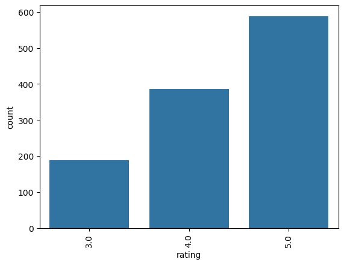

```python
sns.countplot(data=data,x='rating')
plt.xticks(rotation=90)
plt.show()
```

```python
# Check the missing values if they are all from a certain restaurant or customer or day of the week
data.loc[data['rating'].isnull()==True, 'restaurant_name'].value_counts()
```

```
restaurant_name
Shake Shack                    86
The Meatball Shop              48
Blue Ribbon Sushi              46
Blue Ribbon Fried Chicken      32
Parm                           29
                               ..
The Loop                        1
Schnipper's Quality Kitchen     1
Go! Go! Curry!                  1
Market Table                    1
Amy Ruth's                      1
Name: count, Length: 134, dtype: int64
```

```python
 data.loc[data['rating'].isnull()==True, 'customer_id'].value_counts()
```

```
customer_id
52832     6
83287     5
97079     4
47440     3
186473    3
         ..
58231     1
38116     1
304509    1
41136     1
35309     1
Name: count, Length: 599, dtype: int64
```

```python
data.loc[data['rating'].isnull()==True, 'day_of_the_week'].value_counts()
```

```
day_of_the_week
Weekend    529
Weekday    207
Name: count, dtype: int64
```

```python
#No pattern detected; remove the rows without rating
new_data = data[data['rating'].notnull()]
```

```python
new_data.isnull().sum()
```

```
order_id                 0
customer_id              0
restaurant_name          0
cuisine_type             0
cost_of_the_order        0
day_of_the_week          0
rating                   0
food_preparation_time    0
delivery_time            0
dtype: int64
```

### **Question 4:** Check the statistical summary of the data. What is the minimum, average, and maximum time it takes for food to be prepared once an order is placed? [2 marks]

```python
data.describe().T
```

|  | count | mean | std | min | 25% | 50% | 75% | max |
| --- | --- | --- | --- | --- | --- | --- | --- | --- |
| order_id | 1898.0 | 1.477496e+06 | 548.049724 | 1476547.00 | 1477021.25 | 1477495.50 | 1.477970e+06 | 1478444.00 |
| customer_id | 1898.0 | 1.711685e+05 | 113698.139743 | 1311.00 | 77787.75 | 128600.00 | 2.705250e+05 | 405334.00 |
| cost_of_the_order | 1898.0 | 1.649885e+01 | 7.483812 | 4.47 | 12.08 | 14.14 | 2.229750e+01 | 35.41 |
| rating | 1162.0 | 4.344234e+00 | 0.741478 | 3.00 | 4.00 | 5.00 | 5.000000e+00 | 5.00 |
| food_preparation_time | 1898.0 | 2.737197e+01 | 4.632481 | 20.00 | 23.00 | 27.00 | 3.100000e+01 | 35.00 |
| delivery_time | 1898.0 | 2.416175e+01 | 4.972637 | 15.00 | 20.00 | 25.00 | 2.800000e+01 | 33.00 |

#### Observations:

- Food preparation from this data takes minimum 20 minutes, maximum 35 minutes which an average of 27.3 minutes.
- The statistical summary of order_id and customer_id can be ignored since they are unqiue identifying IDs
- The average cost of an order is 16.4, with the maximum being 35.41, not too far from the 3rd quartile. It may be only slightly right skewed, if at all.
- The average rating is 4.3, but ranging only between 3 and 5.
- Delivery time is minimum 15 minutes, maximum 33 minutes with an average of 24.1 minutes. The minimum and maximum aren't unusually small or large, indicating a possibly normal distribution.

### **Question 5:** How many orders are not rated? [1 mark]

```python
data['rating'].value_counts(dropna=False)
```

```
rating
NaN    736
5.0    588
4.0    386
3.0    188
Name: count, dtype: int64
```

#### Observations:

- 736 orders are not rated

### Exploratory Data Analysis (EDA)

### **Question 6:** Explore all the variables and provide observations on their distributions. (Generally, histograms, boxplots, countplots, etc. are used for univariate exploration.) [9 marks]

```python
# We will start by using the new data after treating the missing values
data = new_data
data['rating'].value_counts(dropna=False)
```

```
rating
5.0    588
4.0    386
3.0    188
Name: count, dtype: int64
```

#### Order ID

```python
# Unique ID of the order, which is neither numerical nor categorical
data['order_id'].nunique()
```

```
1162
```

- The column is a unique identifier and there are 1162 rows, which means that there is one row for each order i.e. no duplicates

#### Customer ID

```python
# Unique ID of the order, which is neither numerical nor categorical
data['customer_id'].nunique()
```

```
859
```

- The column is a unique identifier for a customer, which means there are 859 customers in the database who made these orders.
- Since both ID columns have no statistical or aggregative properties, we can conclude the univariate analysis just with seeing how many unique orders and customers we have.

#### Restaurant name

```python
#Unique number of restaurants
data['restaurant_name'].nunique()
```

```
156
```

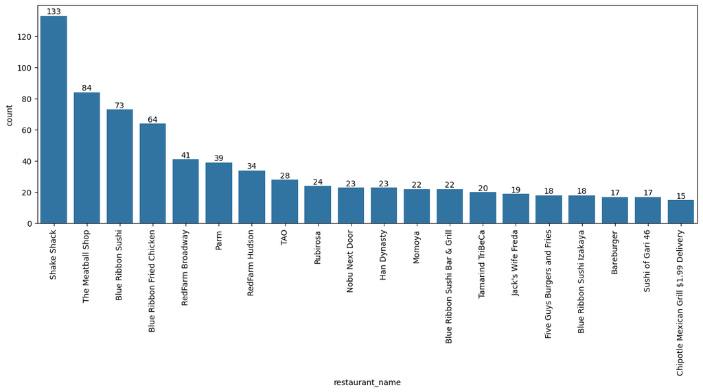

```python
#Count plot of the top 20 restuarants
plt.figure(figsize = (15,5))
ax = sns.countplot(data=data,x='restaurant_name', order=data.restaurant_name.value_counts().iloc[:20].index)
plt.xticks(rotation=90)
ax.bar_label(ax.containers[0])
plt.show()
```

```python
#Percentage distribution of the restuarants
data['restaurant_name'].value_counts(normalize=True) * 100
```

```
restaurant_name
Shake Shack                    11.445783
The Meatball Shop               7.228916
Blue Ribbon Sushi               6.282272
Blue Ribbon Fried Chicken       5.507745
RedFarm Broadway                3.528399
                                 ...
Philippe Chow                   0.086059
Dirty Bird To Go (archived)     0.086059
The MasalaWala                  0.086059
Kambi Ramen House               0.086059
'wichcraft                      0.086059
Name: proportion, Length: 156, dtype: float64
```

- There are 156 unique restaurants in the data, which are too many to show on a bar graph.
- Looking at just the top 20 restaurants, we can see that 'Shake Shack', 'The Meatball Shop', 'Blue Ribbon Sushi', 'Blue Ribbon Fried Chicken are the restaurants with the most orders. These 4 restaurants alone form about 30% of the orders.

#### Cuisine type

```python
#Number of unique cuisine types
data['cuisine_type'].nunique()
```

```
14
```

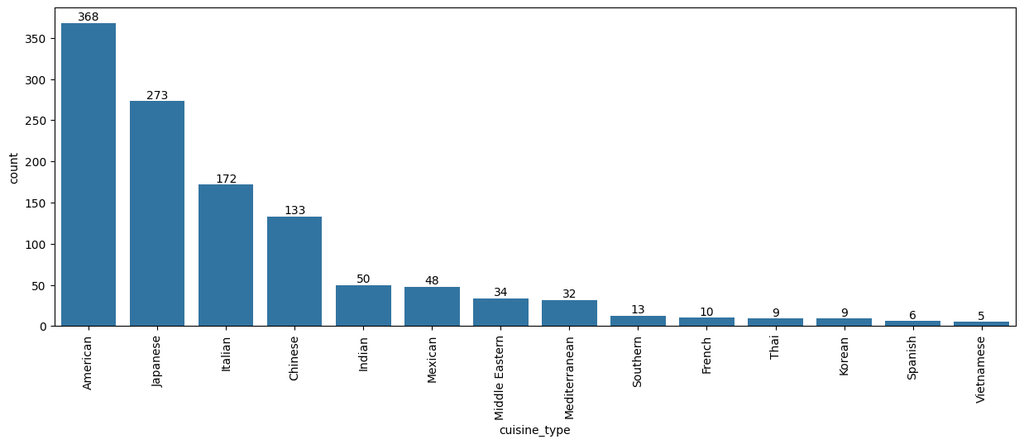

```python
#Count plot of the different cuisine types
plt.figure(figsize = (15,5))
ax = sns.countplot(data=data,x='cuisine_type', order=data.cuisine_type.value_counts().index)
plt.xticks(rotation=90)
ax.bar_label(ax.containers[0])
plt.show()
```

```python
#Percentage distribution of the cuisine types
data['cuisine_type'].value_counts(normalize=True) * 100
```

```
cuisine_type
American          31.669535
Japanese          23.493976
Italian           14.802065
Chinese           11.445783
Indian             4.302926
Mexican            4.130809
Middle Eastern     2.925990
Mediterranean      2.753873
Southern           1.118761
French             0.860585
Thai               0.774527
Korean             0.774527
Spanish            0.516351
Vietnamese         0.430293
Name: proportion, dtype: float64
```

- There are 14 types of cuisine in the data.
- The most common ones are American (31%) and Japanese (23%), the least popular cuisines are French, Thai, Korean, Spanish and Vietnamese. There is a clear preference of cuisine while ordering food. Between American and Japanese cuisine types, they account for the type of cuisine preferred in over 50% of the orders.

#### Cost of the order

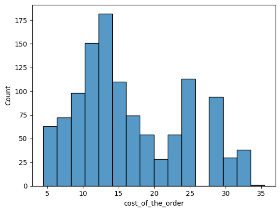

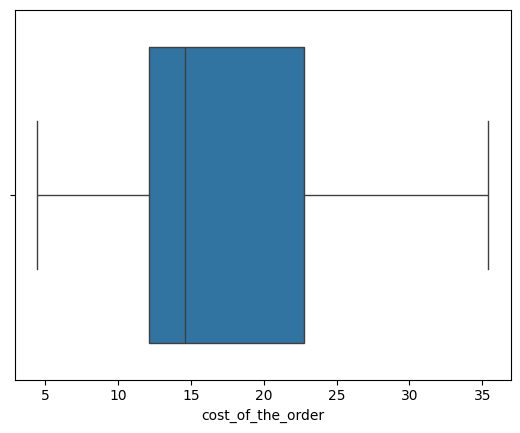

```python
#Distribution of cost in histogram and boxplot
sns.histplot(data=data,x='cost_of_the_order')
plt.show()
sns.boxplot(data=data,x='cost_of_the_order')
plt.show()
```

#### Day of the week

```python
#Unique values in the day of the week column
data['day_of_the_week'].nunique()
```

```
2
```

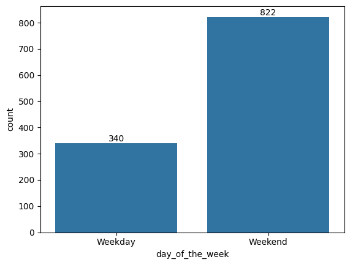

```python
#Bar graph of number of orders in each day of the week
ax = sns.countplot(data = data, x = 'day_of_the_week')
ax.bar_label(ax.containers[0])
plt.show()
```

- The data only registers whether the order was made on a weekday or a weekend.
- 822 orders were made on a weekend and 340 orders on a weekday.
- Many of the orders are made on the weekend, which is expected and indicates that customers prefer to order food during the weekend.